# Hackaton_Crochet_Watrigant

Albert de Watrigant

11/12/2021

```r
data = read.csv(file='C:/Users/dewat/OneDrive/Documents/Machine Learning/data.csv/data.csv')
test = read.csv(file='C:/Users/dewat/OneDrive/Documents/Machine Learning/data.csv/test.csv')
```

## Understand the datas

```r
str(data)
```

```
## 'data.frame':    67502 obs. of  11 variables:
##  $ SeriousDlqin2yrs                    : int  0 0 0 0 0 0 0 0 0 0 ...
##  $ RevolvingUtilizationOfUnsecuredLines: num  0.957 0.658 0.907 0.213 0.754 ...
##  $ age                                 : int  40 38 49 74 39 57 30 46 43 43 ...
##  $ NumberOfTime30_59DaysPastDueNotWorse: int  0 1 1 0 0 0 0 0 0 0 ...
##  $ DebtRatio                           : num  0.115 0.0817 0.0246 0.3189 0.1906 ...
##  $ MonthlyIncome                       : num  7.86 8.02 11.06 8.16 8.16 ...
##  $ NumberOfOpenCreditLinesAndLoans     : int  4 2 7 3 8 9 5 13 7 10 ...
##  $ NumberOfTimes90DaysLate             : int  0 1 0 0 0 0 0 0 0 0 ...
##  $ NumberRealEstateLoansOrLines        : int  0 0 1 1 0 4 0 2 1 2 ...
##  $ NumberOfTime60_89DaysPastDueNotWorse: int  0 0 0 0 0 0 0 0 0 0 ...
##  $ NumberOfDependents                  : int  1 0 0 1 0 2 0 2 2 0 ...
```

```r
dim(data)
```

```
## [1] 67502    11
```

```r
dim(test)
```

```
## [1] 1456   10
```

```r
sum(is.na(data))
```

```
## [1] 159115
```

```r
data = na.omit(data)
sum(is.na(data))
```

```
## [1] 0
```

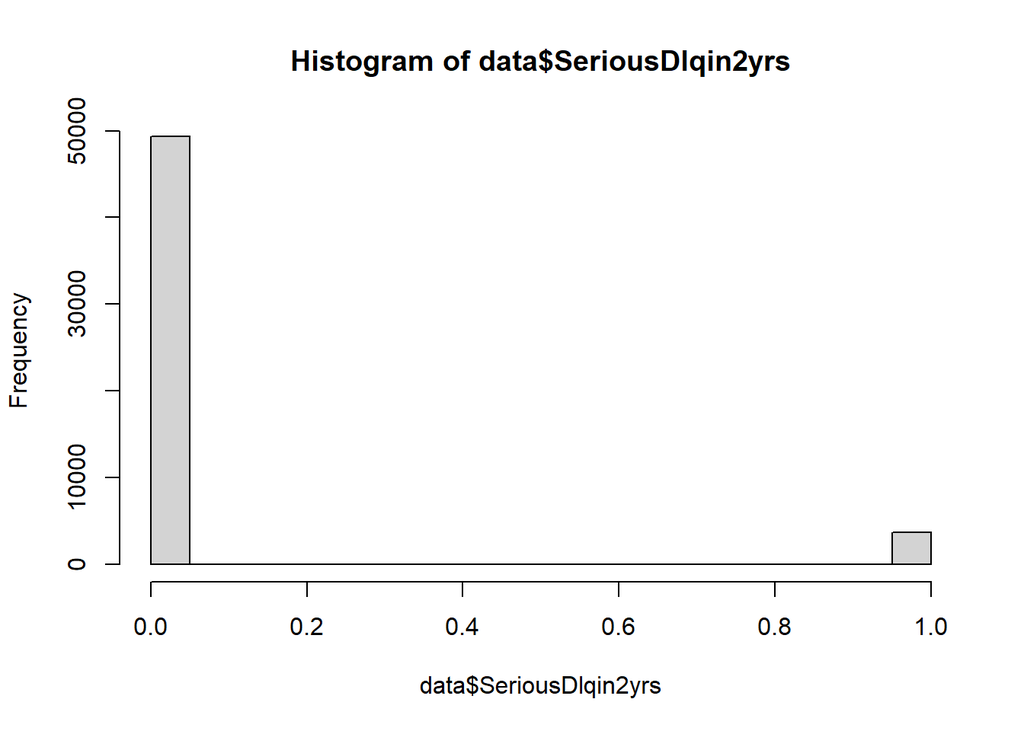

```r
hist(data$SeriousDlqin2yrs)
```

## Show the correlations between the variables

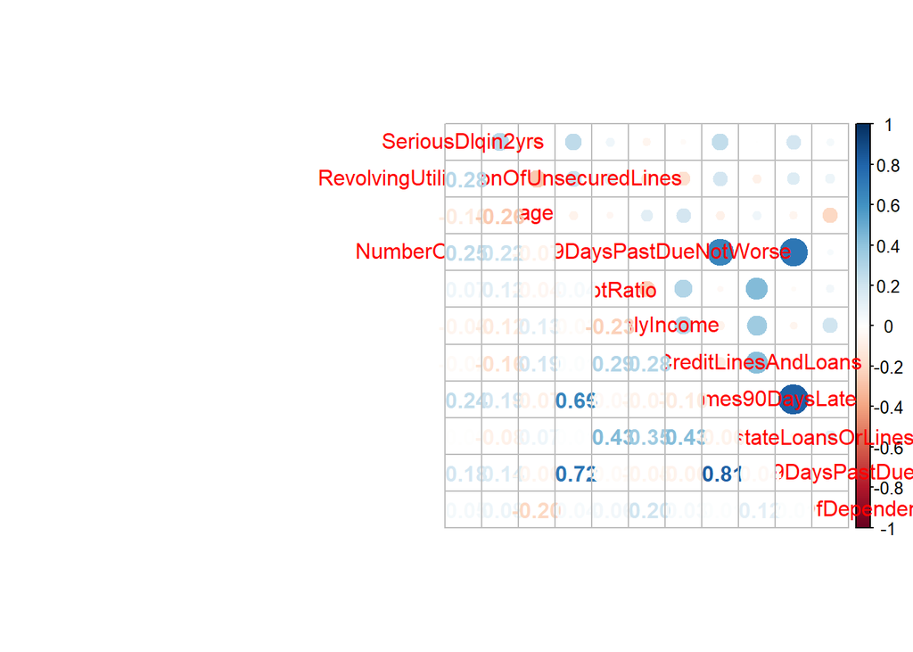

```r
library(corrplot)
M=cor(data)
corrplot.mixed(M)
```

```r
best=abs(cor(data[ , colnames(data) !="SeriousDlqin2yrs"], data$SeriousDlqin2yrs))
best_sorted=best[order(-best[,1]),]
best_sorted
```

```
## RevolvingUtilizationOfUnsecuredLines NumberOfTime30_59DaysPastDueNotWorse
##                         0.2765973296                         0.2500160545
##              NumberOfTimes90DaysLate NumberOfTime60_89DaysPastDueNotWorse
##                         0.2423377817                         0.1831231699
##                                  age                            DebtRatio
##                         0.1025083216                         0.0681010656
##                        MonthlyIncome                   NumberOfDependents
##                         0.0583242021                         0.0490493255
##      NumberOfOpenCreditLinesAndLoans         NumberRealEstateLoansOrLines
##                         0.0244513205                         0.0002413579
```

## PCA

```r
library(FactoMineR)
library(factoextra)
```

```r
#res.pca <- PCA(data[,-14],  graph = FALSE)
res.pca <- prcomp(data[,-1], scale=TRUE)

get_eig(res.pca)
```

```
##        eigenvalue variance.percent cumulative.variance.percent
## Dim.1   2.5949800        25.949800                    25.94980
## Dim.2   1.8987233        18.987233                    44.93703
## Dim.3   1.4166352        14.166352                    59.10338
## Dim.4   1.2462061        12.462061                    71.56545
## Dim.5   0.7771671         7.771671                    79.33712
## Dim.6   0.6769450         6.769450                    86.10657
## Dim.7   0.5752146         5.752146                    91.85871
## Dim.8   0.3430842         3.430842                    95.28956
## Dim.9   0.2939290         2.939290                    98.22884
## Dim.10  0.1771155         1.771155                   100.00000
```

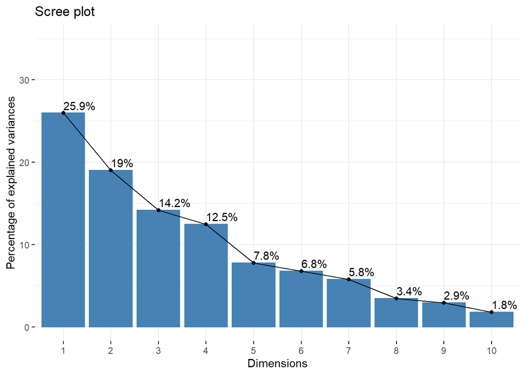

```r
fviz_screeplot(res.pca, addlabels = TRUE, ylim = c(0, 35))
```

As we can see, the first dimensions explain less than 50% of the variance, so we will not use the PCA in order to predict variables

```r
var <- get_pca_var(res.pca)
head(var$coord)
```

```
##                                            Dim.1       Dim.2      Dim.3
## RevolvingUtilizationOfUnsecuredLines -0.38184383 -0.09825798  0.5482521
## age                                   0.22757376  0.18193943 -0.6242973
## NumberOfTime30_59DaysPastDueNotWorse -0.82689008  0.26916621 -0.1008174
## DebtRatio                             0.04677226  0.49537461  0.6059698
## MonthlyIncome                         0.20458933  0.48015105 -0.3864387
## NumberOfOpenCreditLinesAndLoans       0.25056559  0.73148984 -0.0757569
##                                            Dim.4        Dim.5        Dim.6
## RevolvingUtilizationOfUnsecuredLines -0.10685935  0.670657023 -0.262808130
## age                                   0.36617504  0.105033540 -0.606676170
## NumberOfTime30_59DaysPastDueNotWorse  0.02894746  0.006639513 -0.004775881
## DebtRatio                             0.48903330 -0.135060082 -0.105333240
## MonthlyIncome                        -0.60985707  0.313042199  0.104222667
## NumberOfOpenCreditLinesAndLoans       0.13806353  0.035802726  0.071237061
##                                            Dim.7         Dim.8        Dim.9
## RevolvingUtilizationOfUnsecuredLines  0.07786557 -0.0541567897  0.063307200
## age                                  -0.10818869  0.0033341441  0.021685344
## NumberOfTime30_59DaysPastDueNotWorse  0.08304318  0.4673496035  0.006629733
## DebtRatio                            -0.10460434 -0.0016096304 -0.325227691
## MonthlyIncome                        -0.09561678  0.0008230749 -0.297203897
## NumberOfOpenCreditLinesAndLoans       0.59695054 -0.0881334333  0.082852814
##                                             Dim.10
## RevolvingUtilizationOfUnsecuredLines -0.0262423737
## age                                  -0.0016493780
## NumberOfTime30_59DaysPastDueNotWorse  0.0858928537
## DebtRatio                             0.0030620416
## MonthlyIncome                         0.0025511775
## NumberOfOpenCreditLinesAndLoans      -0.0005170399
```

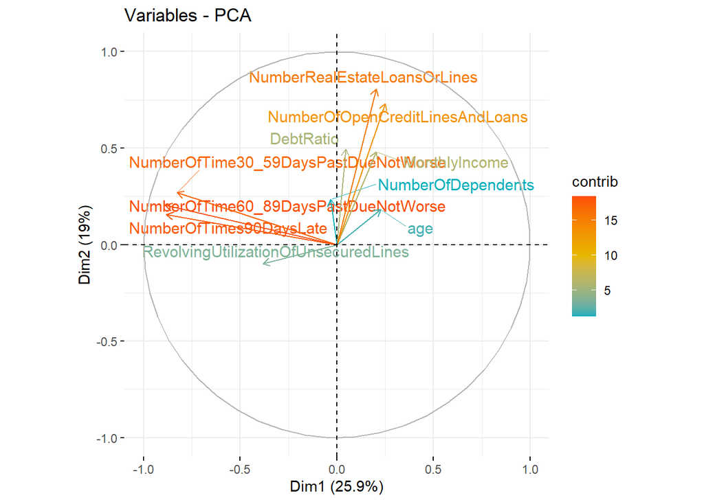

```r
#fviz_pca_var(res.pca, col.var = "black")

fviz_pca_var(res.pca, col.var="contrib",
             gradient.cols = c("#00AFBB", "#E7B800", "#FC4E07"),
             repel = TRUE # Avoid text overlapping
)
```

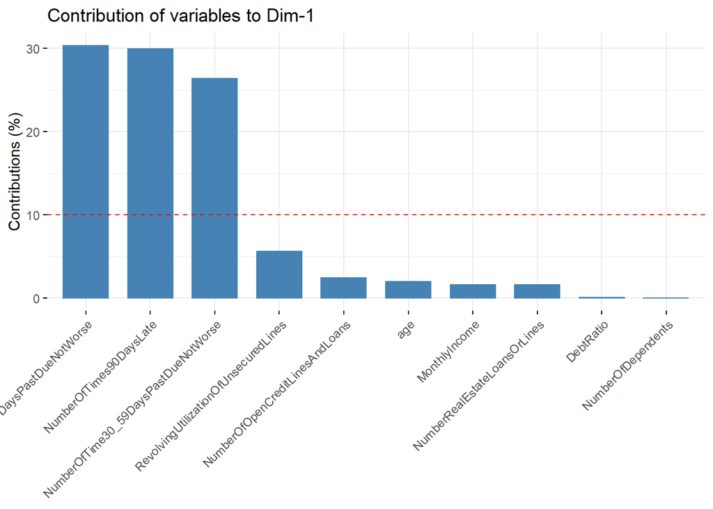

```r
# Contributions of variables to PC1
fviz_contrib(res.pca, choice = "var", axes = 1, top = 10)
```

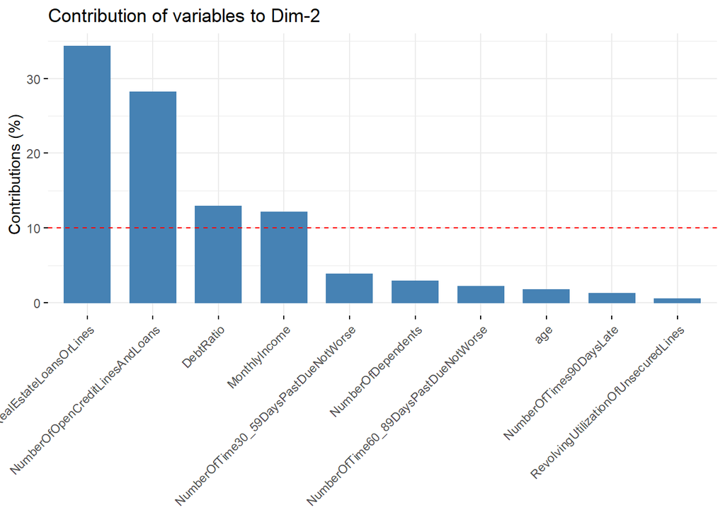

```r
# Contributions of variables to PC2
fviz_contrib(res.pca, choice = "var", axes = 2, top = 10)
```

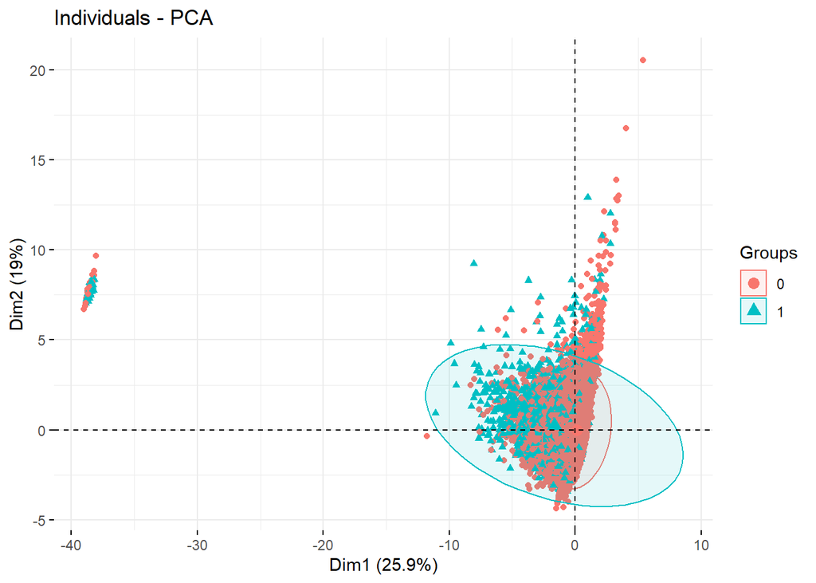

```r
fviz_pca_ind(res.pca,
             habillage = data$SeriousDlqin2yrs,
             addEllipses = TRUE,
             ellipse.level=0.95,
             repel = TRUE,
             label="none",
             geom="point",

             )
```

We didn’t plot the biplot because it was illisible, we can see that group 1 depends on dim1

### Split data in train and testing sets

```r
library(caTools)
set.seed(1234)
split = sample.split(data, SplitRatio = 0.75)
train = subset(data, split == TRUE)
testing = subset(data, split == FALSE)
```

## Scale the values

```r
train[,colnames(train)!="SeriousDlqin2yrs"]=scale(train[,colnames(train)!="SeriousDlqin2yrs"])
testing[,colnames(testing)!="SeriousDlqin2yrs"]=scale(testing[,colnames(testing)!="SeriousDlqin2yrs"])
```

## Our models

```r
calc_acc = function(predicted, actual) {
  mean(predicted == actual)
}
```

# GLM

We started by using a simple logistic regression. We had good results, which shows that sometimes nothing is better than simplicity.

```r
classifier <- glm(formula = SeriousDlqin2yrs ~ ., family = binomial, data = train)
pred_prob <- predict(classifier, testing, type = "response")
pred <- ifelse(pred_prob>0.35, 1,0)

glm_pred<-calc_acc(pred, testing$SeriousDlqin2yrs)
glm_pred
```

```
## [1] 0.9340431
```

New attributes for GLM

After that, we have tried to keep only the variables well correlated with the target. For the first two variables, we thought of squaring them to increase the importance of the variations. This was not very significant.

```r
classifier <- glm(formula = SeriousDlqin2yrs ~ RevolvingUtilizationOfUnsecuredLines**2 + NumberOfTime30_59DaysPastDueNotWorse**2 + NumberOfTimes90DaysLate + NumberOfTime60_89DaysPastDueNotWorse + log(age) + DebtRatio, family = binomial, data = train)
pred_prob <- predict(classifier, testing, type = "response")
pred <- ifelse(pred_prob>0.35, 1,0)

calc_acc(pred, testing$SeriousDlqin2yrs)
```

```
## [1] NA
```

# RPART

Then we tried the decision tree algorithm. The results were consistent with the logistic regression.

```r
library(rpart)
classifier <- rpart(formula = SeriousDlqin2yrs ~ ., data = train)
pred_prob <- predict(classifier, testing)
pred <- ifelse(pred_prob>0.35, 1,0)

rpart_pred<-calc_acc(pred, testing$SeriousDlqin2yrs)
rpart_pred
```

```
## [1] 0.9348728
```

# Random Forest

We tried to use Random Forest which is an algorithm known to have good results. However, its execution took too much time so we had to force its stop.

```r
#library(randomForest)
#forest = randomForest(SeriousDlqin2yrs ~ ., data = train, mtry = 3,
#                        importance = TRUE, ntrees = 100)
#forest
#forest_pred =predict(forest, testing)
#forest_pred = ifelse(forest_pred >= 0.5, 1,0)
#acc_forest = calc_acc(forest_pred, testing$SeriousDlqin2yrs)
```

# Neural network

We wanted to try neural networks to see if it would be effective in our case. Unfortunately, the algorithm is much too slow when there are many lines, so we could only test it with a small sample of the train set. Despite this disappointment, the results were good and with more time, we would have liked to try to run it on the whole dataset.

```r
#install.packages("neuralnet")
require(neuralnet)
classifier <- neuralnet(formula = SeriousDlqin2yrs ~ .,data=train[0:10000,], hidden=3,act.fct = "logistic",linear.output = FALSE)

pred_prob <- predict(classifier, testing)
pred <- ifelse(pred_prob>0.35, 1,0)

neural_pred<-calc_acc(pred, testing$SeriousDlqin2yrs)
neural_pred
```

```
## [1] 0.926922
```

# GBM

Finally, we ended up using the Gradient Boosting algorithm. This is the model that gave us the best performance.We tried many combinations of parameters to maximize our final results. The best distribution seemed to be the gaussian one.

```r
library(gbm)
boost = gbm(SeriousDlqin2yrs ~ . - NumberRealEstateLoansOrLines - NumberOfOpenCreditLinesAndLoans - NumberOfDependents, data = train , distribution = "gaussian", n.trees = 304, interaction.depth = 4, shrinkage = 0.0092)
pred_prob <- predict(boost, testing)
```

```
## Using 304 trees...
```

```r
pred <- ifelse(pred_prob>0.5, 1,0)
boost_pred<-calc_acc(pred, testing$SeriousDlqin2yrs)
boost_pred
```

```
## [1] 0.9364629
```

We also wanted to try the xgboost one but it works on matrix not dataframe, so we didn’t have the time to implement the change.

```r
acc = data.frame(
  Model = c("Single Tree", "Logistic Regression","Neural Network",  "Boosting"),
  TestAccuracy = c(rpart_pred, glm_pred, neural_pred, boost_pred)
  )
knitr::kable(acc)
```

| Model | TestAccuracy |
| --- | --- |
| Single Tree | 0.9348728 |
| Logistic Regression | 0.9340431 |
| Neural Network | 0.9269220 |
| Boosting | 0.9364629 |